# ML Regression Wrap Up

[figure not shown]

## Libraries

```python
import numpy as np
import pandas as pd
import matplotlib.pyplot as plt
```

## Load Data

This data should be clean and prepared for applying ML.

```python
df = pd.read_csv('assets/diabetes.csv')
```

## Train / Test

- We can emulate unseen data by splitting our data into **train** and **test** sets.
  - Use the train set for fitting (training) our model.
  - Use the test set for evaluating our model's performance on unseen data.
- Usual test sizes are 10-30% of the initial data.
  - Large datasets may require a smaller percentage (e.g., 10-20%).
  - Smaller datasets may need a larger test set to ensure that it is representative (e.g., 30-40%).

[figure not shown]

Save the test set for later, do not touch it while tunning models!

```python
from sklearn.model_selection import train_test_split
```

```python
X = df.drop('target', axis=1)
y = df['target']

# Train / Test split
X_train, X_test, y_train, y_test = train_test_split(X, y, test_size=0.2, random_state=42)
```

## Cross-validation

- Prepare `sklearn`'s functions for performing cross-validation.
- This is not running any process yet, we only prepare it.

```python
from sklearn.model_selection import KFold, cross_validate
from sklearn.metrics import mean_squared_error, mean_absolute_error
from sklearn.metrics import make_scorer
```

```python
# Declare KFold
kf = KFold(n_splits=5, shuffle=True, random_state=42)
```

```python
# Declare scores (metrics) to be used
scoring = {
    'MSE': make_scorer(mean_squared_error),
    'MAE': make_scorer(mean_absolute_error),
}
```

## Baseline

- Train and evaluate the performance of a baseline model.
- It provides an initial measure of performance.
- Any model you develop should outperform this simple baseline.
- The `cross_validation` function performs the K-fold cross-validation process.

[figure not shown]

```python
from sklearn.dummy import DummyRegressor
```

```python
bl = DummyRegressor(strategy='mean')

cv_results = cross_validate(bl, X_train, y_train, cv=kf,
                            scoring=scoring, return_train_score=True)
```

- `cross_validate()` computes the performance in each of the `K` iterations.
- Returns a dictionary with:
  - `train_{metric_name}` and `test_{metric_name}` arrays.
  - Other cross-validation information.
- Each value corresponds to one of the `K-Fold` cross-validation splits.

```python
cv_results
```

```
{'fit_time': array([0.00075102, 0.00046706, 0.00046515, 0.00047398, 0.00045347]),
 'score_time': array([0.00059175, 0.0005846 , 0.0004499 , 0.0004456 , 0.00044751]),
 'test_MSE': array([5762.51187931, 7151.87779188, 4781.25164429, 5979.01180562,
        7008.62277341]),
 'train_MSE': array([6174.98512399, 5815.5521352 , 6402.66899301, 6107.78501417,
        5849.303375  ]),
 'test_MAE': array([62.86260114, 74.05244231, 58.4312756 , 67.76855124, 71.22155477]),
 'train_MAE': array([66.83101957, 64.98325034, 68.52381671, 66.50356478, 65.02508459])}
```

```python
cv_results['train_MAE']
```

```
array([66.83101957, 64.98325034, 68.52381671, 66.50356478, 65.02508459])
```

```python
cv_results['test_MAE']
```

```
array([62.86260114, 74.05244231, 58.4312756 , 67.76855124, 71.22155477])
```

By averaging, we get an estimation of how the model performs on unseen data.

```python
print('Baseline Performance\n---------------------')

print('Train MSE:', cv_results['train_MSE'].mean().round(1))
print('Validation MSE:', cv_results['test_MSE'].mean().round(1))
print()
print('Train MAE:', cv_results['train_MAE'].mean().round(1))
print('Validation MAE:', cv_results['test_MAE'].mean().round(1))
```

[output not shown]

## Linear Regression

- Each time we train linear regression,
- the model learns the coefficients $w_i$ (based on the features $x_i$):

  $\hat{y} = w_0 + w_1 \cdot x_1 + w_2 \cdot x_2 + \text{...} + w_n \cdot x_n$
- so that the predictions $\hat{y}$ minimize $MSE(y, \hat{y})$.

```python
from sklearn.linear_model import LinearRegression
```

```python
lr = LinearRegression()

cv_results = cross_validate(lr, X_train, y_train, cv=kf,
                            scoring=scoring, return_train_score=True)
```

```python
print('LR Performance\n---------------------')

print('Train MSE:', cv_results['train_MSE'].mean().round(1))
print('Validation MSE:', cv_results['test_MSE'].mean().round(1))
print()
print('Train MAE:', cv_results['train_MAE'].mean().round(1))
print('Validation MAE:', cv_results['test_MAE'].mean().round(1))
```

```
LR Performance
---------------------
Train MSE: 2846.1
Validation MSE: 3074.1

Train MAE: 43.3
Validation MAE: 45.0
```

## k-Nearest Neighbors

- Predict based on the averaged targets of the closest neighbors.
- Remember to scale the data before applying kNN.
- We decide the hyperparameter values:
  - Number of neighbors.
  - Distance formula.
  - Weights.
  - Etc.

```python
from sklearn.neighbors import KNeighborsRegressor
from sklearn.pipeline import Pipeline
from sklearn.preprocessing import MinMaxScaler
```

```python
knn = Pipeline([
    ('scale', MinMaxScaler()),
    ('knn', KNeighborsRegressor(n_neighbors=2, p=1, n_jobs=-1))
])

cv_results = cross_validate(knn, X_train, y_train, cv=kf,
                            scoring=scoring, return_train_score=True)
```

```python
print('kNN Performance\n---------------------')

print('Train MSE:', cv_results['train_MSE'].mean().round(1))
print('Validation MSE:', cv_results['test_MSE'].mean().round(1))
print()
print('Train MAE:', cv_results['train_MAE'].mean().round(1))
print('Validation MAE:', cv_results['test_MAE'].mean().round(1))
```

```
kNN Performance
---------------------
Train MSE: 1578.4
Validation MSE: 4642.6

Train MAE: 30.7
Validation MAE: 53.1
```

- We don't know which are the best hyperparameter values.
- But we can try several:

```python
train_maes = []
valid_maes = []
n_neighbors = range(1, 50)

for i in n_neighbors:
    knn = Pipeline([
        ('scale', MinMaxScaler()),
        ('knn', KNeighborsRegressor(n_neighbors=i, p=1, n_jobs=-1))
    ])

    cv_results = cross_validate(knn, X_train, y_train, cv=kf,
                                scoring=scoring, return_train_score=True)

    train_maes.append(cv_results['train_MAE'].mean().round(1))
    valid_maes.append(cv_results['test_MAE'].mean().round(1))
```

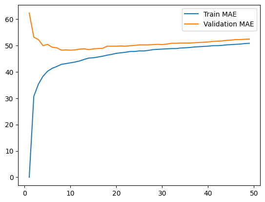

```python
plt.plot(n_neighbors, train_maes, label='Train MAE')
plt.plot(n_neighbors, valid_maes, label='Validation MAE')

plt.legend()
plt.show()
```

We can easily check the best validation MAE:

```python
idx_best = np.argmin(valid_maes)

print(f'Best num. neighbors: {n_neighbors[idx_best]}')
print('Train MAE:', train_maes[idx_best])
print('Validation MAE:', valid_maes[idx_best])
```

```
Best num. neighbors: 8
Train MAE: 42.8
Validation MAE: 48.2
```